# Univariate statistical analyses to identify diffrentially abundant proteins.

Ashfaq Ali

30/11/2021

# Summary

This document contains analyses code to identify differentially abundant proteins using uni variate approach where `limma()` package in R was used to compare abundance differences for following grouping variables.

As batch effect was observed in the in the data and analyses between different time-points maybe confounded by the batch, protein data from the 3 time-points was analysed separately.

1. Temperature (Randomisation code)
2. cpc score (dichotamised)
3. Temperature:CPC score interaction
4. Shockable vs. non-shockable heart

## Import data and perform statistics

## 1) Temperature Randomization code

### Tables

```r
Results <- readRDS("../NBIS_analyses/Results/DEResults.rds")
sig1 <- lapply(Results, function(x) {dplyr::filter(x, adj.P.Val<0.05)})
#sig1 <- within(sig1, rm(All_rand, All_pcscore))
#sig_rand <-
sig1List <- unlist(lapply(Results, function(x) {dplyr::filter(x, adj.P.Val<0.05) %>% rownames(x)}), use.names = FALSE) %>% unique() ## Extract significant proteins at all time points

rowData(data_all)$variance <- assays(data_all)$loess %>% rowVars(na.rm = TRUE)
data_f <- data_all[rownames(data_all) %in% sig1List, ]
```

#### Association with randomization code at 24 h

No significant associations were found at 24h with temperature randomization.

```r
#DT::datatable(round(sig1$rand_24,5))
```

#### Association with randomization code at 48 h

Six proteins were associated with temperature randomization at 48h

```r
DT::datatable(round(sig1$rand_48,5))
```

|  | logFC | AveExpr | t | P.Value | adj.P.Val | B |
| --- | --- | --- | --- | --- | --- | --- |
| Q15485 | 0.56749 | 14.1008 | 4.63247 | 2e-05 | 0.00651 | 2.84554 |
| Q8NBP7 | 0.88216 | 12.37959 | 4.09609 | 0.00011 | 0.02235 | 1.06046 |
| Q14624 | 0.33 | 21.37663 | 3.96693 | 0.00017 | 0.02328 | 0.64975 |
| P03950 | 0.83593 | 13.4349 | 3.59084 | 0.00062 | 0.04823 | -0.50282 |
| P48740-2 | -0.61286 | 13.95568 | -3.56649 | 0.00066 | 0.04823 | -0.56978 |
| P12109 | 0.40212 | 12.04755 | 3.53849 | 0.00072 | 0.04823 | -0.65181 |

#### Association with randomization code at 72 h

No significant associations with temperature randomization were found at 72h.

```r
#DT::datatable(round(sig1$rand_72,5))
```

### Heat Plots for randomization code

We selected all proteins significantly regulated with randomization code. In this analyses 6 Proteins associated with randomization code were found only at 48 timepoint.

#### Heatmap of siginificatly associated protein with temperature randomization

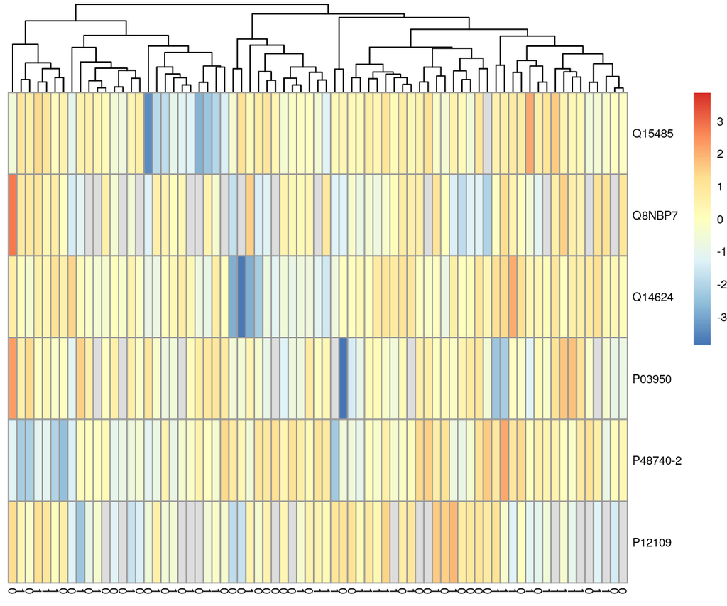

```r
### Heatmap for significantly DE proteins
sig_rand <- unlist(lapply(sig1[1:3], rownames, usenames)) %>% as.vector()
#intData <- assays(data_24h)$loess[sig_rand,]
intData <- data_24h[sig_rand,]
#png("../Results/Figures/HeatmapInt.png", units = "cm", height = 30, width = 30,res = 300)
pheatmap(assays(intData)$loess,
         display_numbers=FALSE,
         fontsize=7,
         cluster_cols=TRUE,
         cluster_rows = FALSE,
         scale = "row",
         labels_col =  intData$randomisation_code)
```

```r
#dev.off()
```

#### Heatmap of foldchanges at 3 timepoints

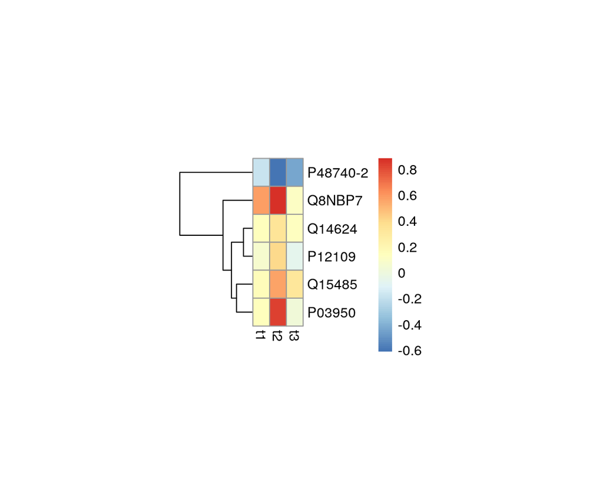

Heatmap of foldchanges at 3 timepoints

```r
fcc <- as.matrix(bind_cols(Results$rand24[sig_rand,]$logFC,
                           Results$rand_48[sig_rand,]$logFC,
                           Results$rand72[sig_rand,]$logFC
                           )
                 )

dimnames(fcc) <- list(sig_rand, c("t1", "t2", "t3") )
pheatmap(fcc,
         cluster_cols = FALSE,
         cellwidth = 12,
         cellheight = 20)
```

## 2) Results for cpc score phenotype variable tables

### 2A) Tables

In total 29 proteins were significantly regulated at 24h timepoint in association with PCS score.

```r
DT::datatable(round(head(Results$pcscore24, 10),5))
```

|  | logFC | AveExpr | t | P.Value | adj.P.Val | B |
| --- | --- | --- | --- | --- | --- | --- |
| Q9UGM5 | -0.40449 | 15.70953 | -4.24884 | 6e-05 | 0.01219 | 1.57853 |
| P18065 | 0.9923 | 14.35081 | 4.16544 | 8e-05 | 0.01219 | 1.30282 |
| Q12805 | 0.45332 | 15.47681 | 4.14071 | 9e-05 | 0.01219 | 1.22171 |
| P01034 | 0.50914 | 15.18589 | 3.85143 | 0.00025 | 0.01892 | 0.29533 |
| P08519 | -0.55264 | 18.21617 | -3.81231 | 0.00028 | 0.01892 | 0.17336 |
| P00746 | 0.66057 | 15.98633 | 3.78861 | 0.00031 | 0.01892 | 0.09986 |
| P0CG47 | 0.7057 | 13.52303 | 3.76758 | 0.00033 | 0.01892 | 0.03491 |
| P10643 | 0.42216 | 16.84754 | 3.68572 | 0.00043 | 0.0196 | -0.2156 |
| P22105 | -0.51214 | 13.09292 | -3.67866 | 0.00044 | 0.0196 | -0.23704 |
| P07998 | 1.16499 | 12.89192 | 3.6395 | 0.00052 | 0.0196 | -0.35869 |

In total 6 proteins were significantly regulated at 48h timepoint in association with PCS score.

```r
DT::datatable(round(head(Results$pcscore48, 10),5))
```

|  | logFC | AveExpr | t | P.Value | adj.P.Val | B |
| --- | --- | --- | --- | --- | --- | --- |
| P18065 | 1.06875 | 14.40709 | 5.18506 | 0 | 0.0008 | 4.79906 |
| Q16627 | 0.58972 | 13.37388 | 3.86898 | 0.00025 | 0.02877 | 0.34964 |
| P10643 | 0.42956 | 16.95577 | 3.86199 | 0.00025 | 0.02877 | 0.33718 |
| P07988 | 0.70411 | 13.83039 | 3.82239 | 0.00029 | 0.02877 | 0.21053 |
| P19823 | -0.24817 | 20.63303 | -3.66565 | 0.00048 | 0.03363 | -0.25884 |
| P19827 | -0.25272 | 19.43333 | -3.64992 | 0.0005 | 0.03363 | -0.3057 |
| P08294 | 0.78815 | 13.88033 | 3.36849 | 0.00125 | 0.06243 | -1.12149 |
| P80108 | -0.34464 | 15.14448 | -3.34234 | 0.00133 | 0.06243 | -1.19424 |
| P43652 | -0.30936 | 18.35639 | -3.32816 | 0.00139 | 0.06243 | -1.23387 |
| P14625 | 0.41844 | 13.33686 | 3.29026 | 0.00157 | 0.06316 | -1.33923 |

In total 8 proteins were significantly regulated at 72h timepoint in association with PCS score.

```r
DT::datatable(round(head(Results$pcscore72, 10),5))
```

|  | logFC | AveExpr | t | P.Value | adj.P.Val | B |
| --- | --- | --- | --- | --- | --- | --- |
| P06396 | -0.49686 | 18.137 | -4.67864 | 2e-05 | 0.00645 | 2.87947 |
| P01764 | 1.17274 | 18.37103 | 4.07486 | 0.00013 | 0.0267 | 0.9266 |
| Q86XR2 | -0.66103 | 15.76467 | -3.85022 | 0.00028 | 0.03772 | 0.23153 |
| P22692 | 0.39699 | 13.60375 | 3.71744 | 0.00043 | 0.03772 | -0.15836 |
| P43652 | -0.32366 | 18.13637 | -3.6934 | 0.00047 | 0.03772 | -0.22918 |
| P10643 | 0.42513 | 17.13342 | 3.5893 | 0.00065 | 0.04044 | -0.53244 |
| P22891 | -0.68085 | 15.32108 | -3.56621 | 0.0007 | 0.04044 | -0.59898 |
| P18065 | 0.79655 | 14.66261 | 3.48632 | 0.0009 | 0.04549 | -0.82697 |
| P49747 | -0.44792 | 13.43036 | -3.33976 | 0.00142 | 0.06356 | -1.23626 |
| P06331 | 0.65442 | 17.92499 | 3.21048 | 0.0021 | 0.08447 | -1.58728 |

### 2B) Figures

#### Heatmap of significantly associated proteins at all three time-points

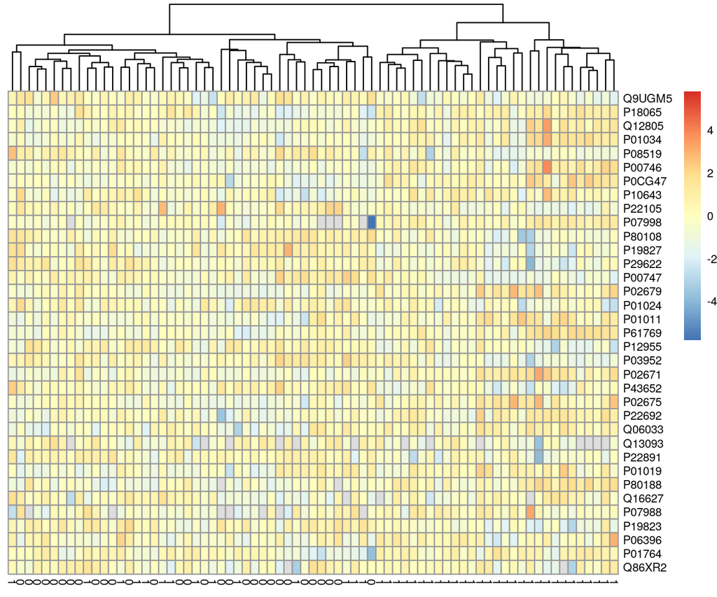

```r
### Heatmap for significantly DE proteins
sig_pcs <- unlist(lapply(sig1[4:6], rownames, usenames)) %>% as.vector() %>% unique()
#intData <- assays(data_24h)$loess[sig_rand,]
intData <- data_24h[sig_pcs,]

#png("../Results/Figures/HeatmapInt.png", units = "cm", height = 30, width = 30,res = 300)
pheatmap(assays(intData)$loess,
         display_numbers=FALSE,
         fontsize=7,
         cluster_cols=TRUE,
         cluster_rows = FALSE,
         scale = "row",
         labels_col =  intData$binarysecout180daycpcscore)
```

```r
#dev.off()
```

#### Heatmap of Foldchanges of significantly associated proteins at three timepoints

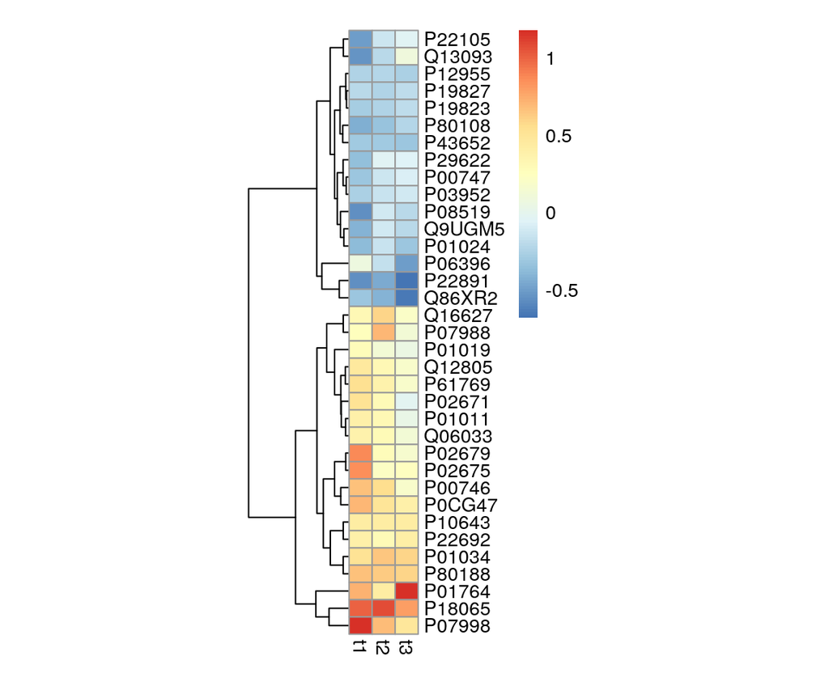

```r
fcc_pcs <- as.matrix(bind_cols(Results$pcscore24[sig_pcs,]$logFC,
                           Results$pcscore48[sig_pcs,]$logFC,
                           Results$pcscore72[sig_pcs,]$logFC
                           )
                 )

dimnames(fcc_pcs) <- list(sig_pcs, c("t1", "t2", "t3") )
pheatmap(fcc_pcs,
         cluster_cols = FALSE,
         cellwidth = 12,
         cellheight = 9)
```

### 2C) PCS * Temperature interaction

[figure not shown]

Boxplot indicating differential effect of temeprature randomization in different CPC score categories on protein P08294 intensity

```r
intData1 <- assays(data_24h)$loess["P08294",]
tDatat <- cbind(as.data.frame(colData(data_24h)),intData1)

# Change the position
p<-ggplot(tDatat, aes(x = as.factor(randomisation_code), y = intData1, fill= as.factor(binarysecout180daycpcscore))) +
  geom_boxplot(position=position_dodge(1)) +
  scale_fill_discrete(name="180 day\nCPC Score",
                         breaks=c("0", "1"),
                         labels=c("Functional", "Impaired"))+
  labs(title="CPC Score*Temperature interaction for\nExtracellular superoxide dismutase(P08294) at 48h", x="Temperature randomization Category" , y= expression("Log"[2]~"protein intensity"))

p <- p +geom_dotplot(binaxis='y', stackdir='center',
                 position=position_dodge(1))

p
```

#### Interaction at 3 timepoints

```r
data_all <- readRDS("../data_sumExpfilImp.rds")
#data_all <- readRDS("../normalized_filtered_se.rds")
data_all_f <- data_all[, (data_all$shockable=="0" | data_all$shockable==1) & !is.na(data_all$shockable)]
rowData(data_all)$variance <- assays(data_all)$loess %>% rowVars(na.rm = TRUE)
#data_all <- data_all[rowData(data_all)$variance>0.2 | rowData(data_all)$variance<5, ]
#saveRDS(data_all_f,"../data_all_f.rds")
data_24h <- data_all_f[, data_all_f$time=="-24-"]
data_48h <- data_all_f[, data_all_f$time=="-48-"]
data_72h <- data_all_f[, data_all_f$time=="-72-"]
```

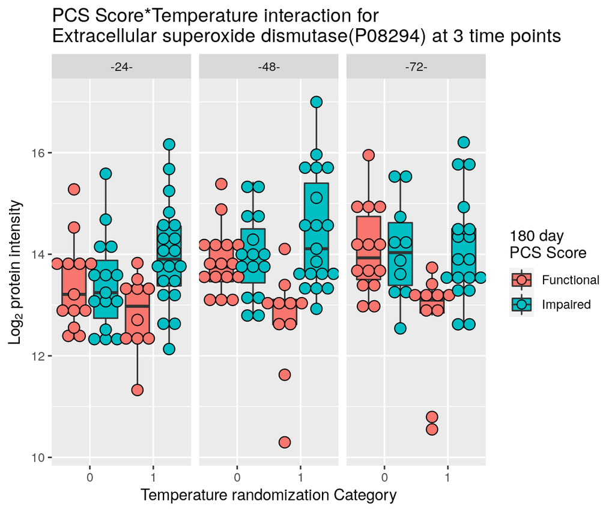

```r
intData2 <- assays(data_all_f)$loess["P08294",]
tDatat2 <- cbind(as.data.frame(colData(data_all_f)),intData2)

p<-ggplot(tDatat2, aes(x = as.factor(randomisation_code), y = intData2, fill= as.factor(binarysecout180daycpcscore))) +
  geom_boxplot(position=position_dodge(1)) +
  scale_fill_discrete(name="180 day\nPCS Score",
                         breaks=c("0", "1"),
                         labels=c("Functional", "Impaired"))+
  labs(title="PCS Score*Temperature interaction for\nExtracellular superoxide dismutase(P08294) at 3 time points", x="Temperature randomization Category" , y= expression("Log"[2]~"protein intensity")) + facet_grid(~time)


p <- p +geom_dotplot(binaxis='y', stackdir='center',
                 position=position_dodge(1))

p
```

##3) Shockable vs.non Shockable differential abundance analyses

### Tables

```r
Results_shock <- readRDS("../NBIS_analyses/Results/Results_shock.rds")
```

#### 24h

In total 34 proteins were significantly regulated at 24h timepoint in association with Shock variable.

```r
Results_shock <- readRDS("../NBIS_analyses/Results/Results_shock.rds")
DT::datatable(round(head(Results_shock$shock24, 10),5))
```

|  | logFC | AveExpr | t | P.Value | adj.P.Val | B |
| --- | --- | --- | --- | --- | --- | --- |
| P19823 | 0.48387 | 20.70092 | 4.89362 | 1e-05 | 0.00239 | 3.60622 |
| P29622 | 0.49847 | 16.69012 | 4.63592 | 2e-05 | 0.00239 | 2.71252 |
| Q9UGM5 | 0.48821 | 15.70495 | 4.63359 | 2e-05 | 0.00239 | 2.70454 |
| P02765 | 0.45603 | 21.22965 | 4.52141 | 3e-05 | 0.00252 | 2.32291 |
| P80108 | 0.57763 | 15.65107 | 4.43319 | 4e-05 | 0.00252 | 2.02611 |
| P02748 | -0.60426 | 19.43374 | -4.42512 | 4e-05 | 0.00252 | 1.99913 |
| P02671 | -0.72181 | 15.72494 | -4.3638 | 5e-05 | 0.00269 | 1.79481 |
| Q96PD5 | 0.47876 | 17.90281 | 4.29947 | 6e-05 | 0.00295 | 1.58213 |
| P01034 | -0.58397 | 15.1643 | -4.23287 | 7e-05 | 0.00331 | 1.36374 |
| P61769 | -0.7406 | 15.37573 | -4.20114 | 8e-05 | 0.00333 | 1.26037 |

#### 48h

In total 4 proteins were significantly regulated at 48h timepoint in association with Shock variable.

```r
DT::datatable(round(head(Results_shock$shock48, 10),5))
```

|  | logFC | AveExpr | t | P.Value | adj.P.Val | B |
| --- | --- | --- | --- | --- | --- | --- |
| P02751-1 | 0.4974 | 19.7082 | 4.44505 | 4e-05 | 0.00852 | 2.0917 |
| P02671 | -0.57538 | 16.30241 | -4.40091 | 4e-05 | 0.00852 | 1.94635 |
| P02765 | 0.51442 | 21.07542 | 4.13337 | 0.00011 | 0.0144 | 1.08187 |
| P19823 | 0.30417 | 20.62371 | 3.88561 | 0.00025 | 0.02489 | 0.30858 |
| Q96PD5 | 0.32942 | 17.79047 | 3.5815 | 0.00066 | 0.05296 | -0.60057 |
| P02748 | -0.38791 | 19.99213 | -3.49663 | 0.00087 | 0.05296 | -0.84581 |
| P00746 | -0.69965 | 16.16912 | -3.44899 | 0.00101 | 0.05296 | -0.98174 |
| P07998 | -0.85157 | 12.83454 | -3.44048 | 0.00105 | 0.05296 | -1.01356 |
| P18065 | -0.83433 | 14.33042 | -3.30267 | 0.00158 | 0.07069 | -1.39133 |
| P27169 | 0.40472 | 18.2423 | 3.25689 | 0.00181 | 0.07307 | -1.51696 |

#### 72h

In total 0 proteins were significantly regulated at 72h timepoint in association with Shock variable.

```r
DT::datatable(round(head(Results_shock$shock72, 10),5))
```

|  | logFC | AveExpr | t | P.Value | adj.P.Val | B |
| --- | --- | --- | --- | --- | --- | --- |
| O75594 | -0.59421 | 11.98649 | -2.94066 | 0.0049 | 0.6809 | -3.87188 |
| P19823 | 0.27996 | 20.64539 | 2.89137 | 0.0055 | 0.6809 | -3.88296 |
| P07478 | 0.54913 | 21.5927 | 2.76384 | 0.00778 | 0.6809 | -3.94732 |
| Q86XR2 | 0.6368 | 15.76258 | 2.64778 | 0.01063 | 0.6809 | -4.00789 |
| Q9UGM5 | 0.39312 | 15.1879 | 2.55484 | 0.01345 | 0.6809 | -4.0492 |
| P27918 | 0.39611 | 15.98179 | 2.51034 | 0.01506 | 0.6809 | -4.07027 |
| O75144 | 0.39956 | 12.18902 | 2.47665 | 0.0164 | 0.6809 | -4.08606 |
| P40197 | -0.58643 | 14.11659 | -2.47692 | 0.01645 | 0.6809 | -4.08875 |
| P04075 | 0.67583 | 14.09062 | 2.40527 | 0.01959 | 0.6809 | -4.11907 |
| Q96PD5 | 0.28985 | 17.62908 | 2.40403 | 0.01965 | 0.6809 | -4.11964 |

### Figures

#### Heatmap of proteins at 24h

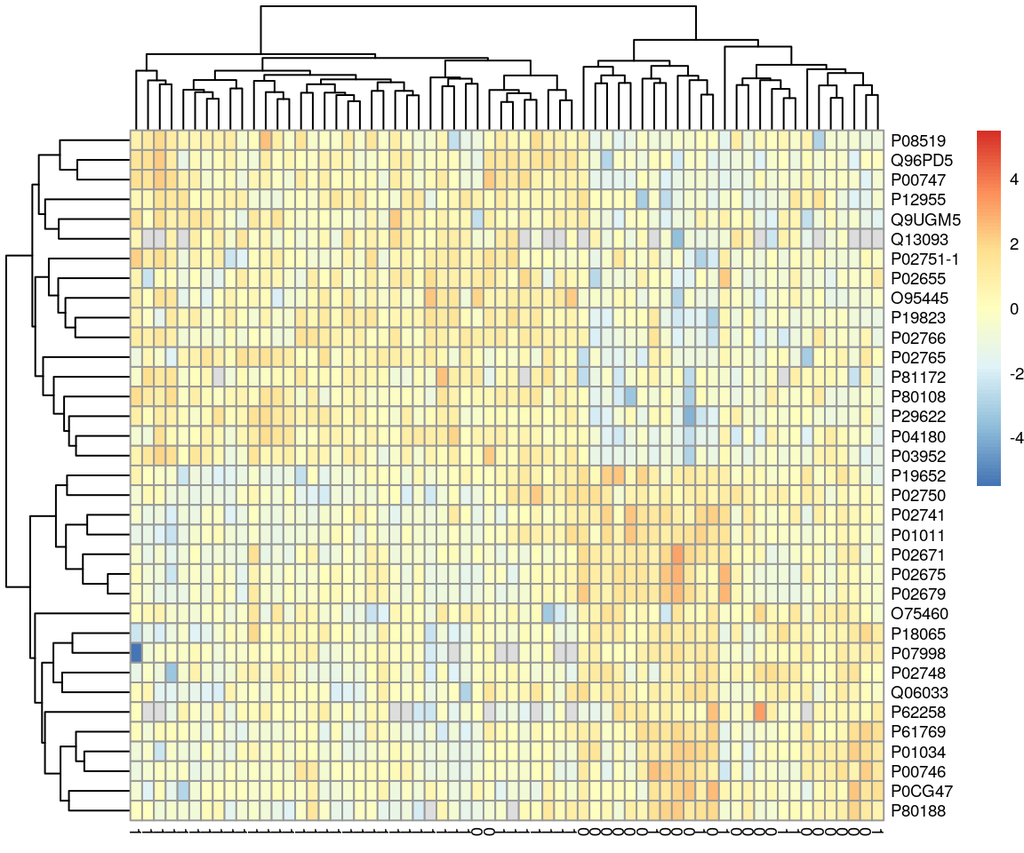

Heat map of Protein instensities in all samples

```r
### Heatmap for significantly DE proteins
sigs <- lapply(Results_shock, function(x) {dplyr::filter(x, adj.P.Val<0.05)})
sig_shock <- unlist(lapply(sigs, rownames, usenames)) %>% as.vector() %>% unique()
#intData <- assays(data_24h)$loess[sig_rand,]
intDatas <- data_24h[sig_shock,]
intDatas
## class: SummarizedExperiment
## dim: 35 64
## metadata(0):
## assays(5): raw_data imputed_raw log2plus1 vsn loess
## rownames(35): P19823 P29622 ... P07998 P02751-1
## rowData names(7): ID PG.ProteinGroups ... PEP.StrippedSequence na_per
## colnames(64): SEHBG0001_1 SEHBG0003_1 ... SEMAL0021_1 SEMAL0022_1
## colData names(266): time sample ... 72h_Comment timepoint
#png("../Results/Figures/HeatmapInt.png", units = "cm", height = 30, width = 30,res = 300)
pheatmap(assays(intDatas)$loess,
         display_numbers=FALSE,
         fontsize=7,
         cluster_cols=TRUE,
         cluster_rows = TRUE,
         scale = "row",
         labels_col =  intDatas$shockable)
```

#### Heatmap of fold changes at 3 timepoints

[figure not shown]

Heat map of Fold Changes at 3 timepoints

```r
fcc_shock <- as.matrix(bind_cols(Results_shock$shock24[sig_shock,]$logFC,
                           Results_shock$shock48[sig_shock,]$logFC,
                           Results_shock$shock72[sig_shock,]$logFC
                           )
                 )

dimnames(fcc_shock) <- list(sig_pcs, c("t1", "t2", "t3") )
pheatmap(fcc_shock,
         cluster_cols = FALSE,
         cellwidth = 12,
         cellheight = 9)
```

```r
sessionInfo()
## R Under development (unstable) (2021-11-16 r81199)
## Platform: x86_64-pc-linux-gnu (64-bit)
## Running under: Ubuntu 20.04.3 LTS
##
## Matrix products: default
## BLAS/LAPACK: /usr/lib/x86_64-linux-gnu/openblas-pthread/libopenblasp-r0.3.8.so
##
## locale:
##  [1] LC_CTYPE=en_US.UTF-8       LC_NUMERIC=C
##  [3] LC_TIME=en_US.UTF-8        LC_COLLATE=en_US.UTF-8
##  [5] LC_MONETARY=en_US.UTF-8    LC_MESSAGES=C
##  [7] LC_PAPER=en_US.UTF-8       LC_NAME=C
##  [9] LC_ADDRESS=C               LC_TELEPHONE=C
## [11] LC_MEASUREMENT=en_US.UTF-8 LC_IDENTIFICATION=C
##
## attached base packages:
## [1] stats4    stats     graphics  grDevices datasets  utils     methods
## [8] base
##
## other attached packages:
##  [1] SummarizedExperiment_1.25.2 Biobase_2.55.0
##  [3] GenomicRanges_1.47.5        GenomeInfoDb_1.31.1
##  [5] IRanges_2.29.1              S4Vectors_0.33.4
##  [7] MatrixGenerics_1.7.0        matrixStats_0.61.0
##  [9] RColorBrewer_1.1-2          pheatmap_1.0.12
## [11] BiocGenerics_0.41.2         DBI_1.1.1
## [13] limma_3.51.0                fuzzyjoin_0.1.6
## [15] readxl_1.3.1                reshape2_1.4.4
## [17] forcats_0.5.1               stringr_1.4.0
## [19] dplyr_1.0.7                 purrr_0.3.4
## [21] readr_2.1.0                 tidyr_1.1.4
## [23] tibble_3.1.6                ggplot2_3.3.5
## [25] tidyverse_1.3.1
##
## loaded via a namespace (and not attached):
##  [1] bitops_1.0-7           fs_1.5.0               lubridate_1.8.0
##  [4] httr_1.4.2             tools_4.2.0            backports_1.4.0
##  [7] utf8_1.2.2             R6_2.5.1               DT_0.20
## [10] colorspace_2.0-2       withr_2.4.2            tidyselect_1.1.1
## [13] compiler_4.2.0         cli_3.1.0              rvest_1.0.2
## [16] xml2_1.3.2             DelayedArray_0.21.2    labeling_0.4.2
## [19] scales_1.1.1           digest_0.6.28          rmarkdown_2.11
## [22] XVector_0.35.0         pkgconfig_2.0.3        htmltools_0.5.2
## [25] highr_0.9              dbplyr_2.1.1           fastmap_1.1.0
## [28] htmlwidgets_1.5.4      rlang_0.4.12           rstudioapi_0.13
## [31] farver_2.1.0           jquerylib_0.1.4        generics_0.1.1
## [34] jsonlite_1.7.2         crosstalk_1.2.0        RCurl_1.98-1.5
## [37] magrittr_2.0.1         GenomeInfoDbData_1.2.7 Matrix_1.3-4
## [40] Rcpp_1.0.7             munsell_0.5.0          fansi_0.5.0
## [43] lifecycle_1.0.1        stringi_1.7.5          yaml_2.2.1
## [46] zlibbioc_1.41.0        plyr_1.8.6             grid_4.2.0
## [49] crayon_1.4.2           lattice_0.20-45        haven_2.4.3
## [52] hms_1.1.1              knitr_1.36             pillar_1.6.4
## [55] reprex_2.0.1           glue_1.5.0             evaluate_0.14
## [58] renv_0.14.0            modelr_0.1.8           vctrs_0.3.8
## [61] tzdb_0.2.0             cellranger_1.1.0       gtable_0.3.0
## [64] assertthat_0.2.1       xfun_0.28              broom_0.7.10
## [67] ellipsis_0.3.2
```